# The {healthyverse}

2022-04-27

## About Me

## Education

- BA Economics: SUNY Stony Brook University
- MPH: SUNY Stony Brook University

## Employment

- Data Scientist/IT Manager: NYU Langone Health at Long Island Community Hospital
- Head Data Scientist: Manchu Technologies Corp. (Consulting in `SQL`, `R`)
- Developer: `healthyverse` packages.
- Researcher: FMTangerman LLC https://www.fmtangerman.com/

## Sites

GitHub: https://github.com/spsanderson

LinkedIn: https://www.linkedin.com/in/spsanderson/

Personal: https://www.spsanderson.com

## Interests

- Data Analysis
- R (probably obvious)
- Plex Server (Music is life) - Is 88K mp3’s to much? NO!

## How I got Started

I got started with R in my first job out of undergrad.

Employer: “Do you know SQL and any other analysis programming?” Me: Yes, not a problem at all.

Reality…a little different, maybe an alternative fact.

SO…Google Searching…saved the day? YES!

## What are we going to talk about

So what are we going to discuss today?

The `healthyverse` suite of packages.

## Healthyverse Packages

There are currently five packages in the `healthyverse`

| Package | r-universe badge |
| --- | --- |
| `healthyR` |  |
| `healthyR.data` |  |
| `healthyR.ai` |  |
| `healthyR.ts` |  |
| `TidyDensity` |  |

The `healthyverse` package is really just a meta package like tidyverse.

## `healthyR`

First came `healthyR`

It is experimental

Site: https://www.spsanderson.com/healthyR/

## LOS RA Index Plot

This plot takes place at the end of a work flow. Let’s take a look at an example. First we need some data.

```
## # A tibble: 186 x 4
##     alos  elos readmit_rate readmit_rate_bench
##    <dbl> <dbl>        <dbl>              <dbl>
##  1  4.82  9.33       0.0768             0.0651
##  2  5.81  6.25       0.141              0.0435
##  3 11.2   8.26       0.126              0.0333
##  4  6.71  4.50       0.0705             0.104
##  5  6.89  6.64       0.0502             0.0206
##  6 11.6   5.03       0.107              0.149
##  7  7.88  6.28       0.0993             0.0157
##  8  2.70  3.31       0.0105             0.0801
##  9  4.44  2.07       0.102              0.102
## 10  5.16 12.0        0.110              0.104
## # ... with 176 more rows
```

## LOS RA Index Plot (summary)

Now that we have our data, let’s take a look at the summary table.

```
## # A tibble: 5 x 4
##   los_group los_index rar_index los_ra_var
##       <dbl>     <dbl>     <dbl>      <dbl>
## 1         0     0          0.6        1.4
## 2         1     0.133      1.83       1.70
## 3         2     0.414      2          1.59
## 4         3     0.488      1.57       1.08
## 5         4     0.662      2.2        1.54
```

## LOS RA Index Plot (plot)

Now lets take a look at the resulting plot and discuss what it tells us.

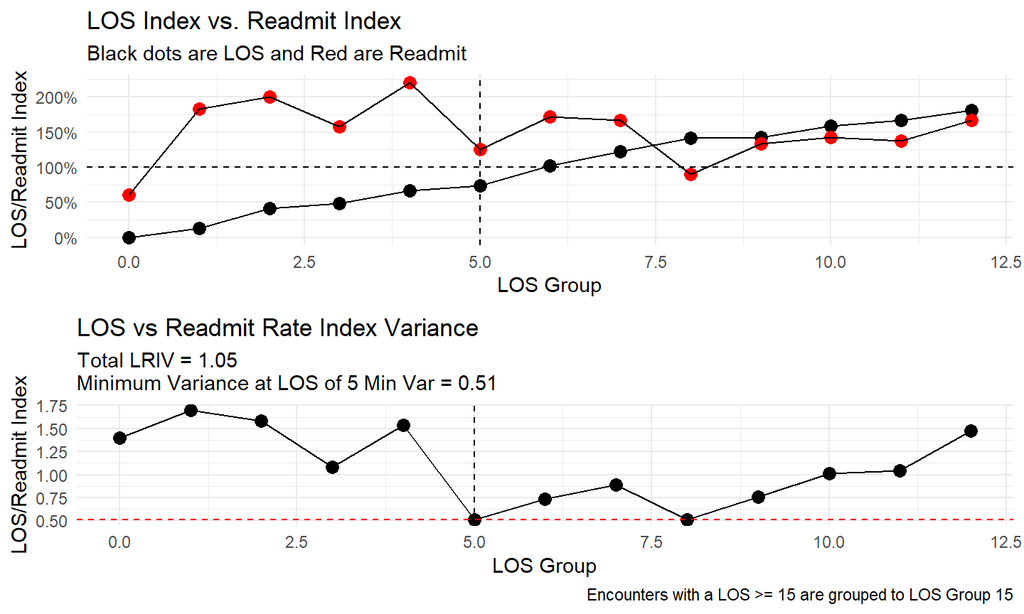

## K-Means

What is it? In it’s simplest form, K-Means will partition data into K non-overlapping clusters.

Example? Think a bank wanting to give people credit cards, this is a clustering problem, high income, average income, low income, etc.

It’s easy to understand how many applications this has.

Healthcare is no different.

## Scree Plot

We are only going to focus on the scree plot. This helps us to decide how many clusters are in our data.

This plot is also many times referred to as the elbow plot.

## Example

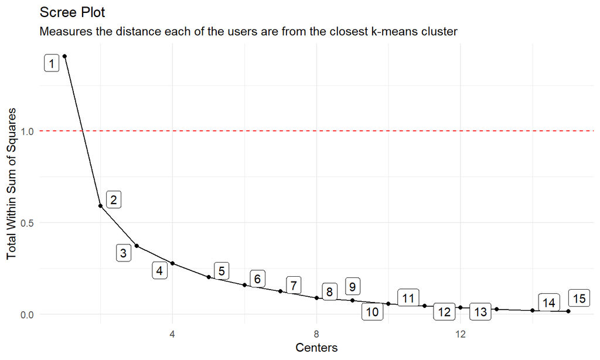

## What Just Happened?

What just happened? Magic? Maybe?

First the data. Using the `healthyR_data` from my package `healthyR.data` we get a tibble of records with a service line and a payer grouping.

A patients service line is the row record and the payer grouping is the item, this gives us the user item matrix we need.

Next we get a tibble with multiple centers via the function `kmeans_mapped_tbl()`

Lastly, we plot that mapped tibble.

## Magic Chart

Have you seen the Gartner Magic Quadrant Chart?

If so, then you know, if not, then I’ll show.

First let’s take a look at the function call.

## Function Call

```r
gartner_magic_chart_plt(
  .data = tibble::tibble(
      x = rnorm(100, 0, 1)
      , y = rnorm(100,0,1)
  )
  , .x_col = x
  , .y_col = y
  , .x_lab = "LOS"
  , .y_lab = "Readmit"
  , .plt_title = "Test Plot"
  , .tr_lbl = "High RA-LOS"
  , .tl_lbl = "High RA"
  , .bl_lbl = "Leader"
  , .br_lbl = "High LOS"
)
```

## Plot Output

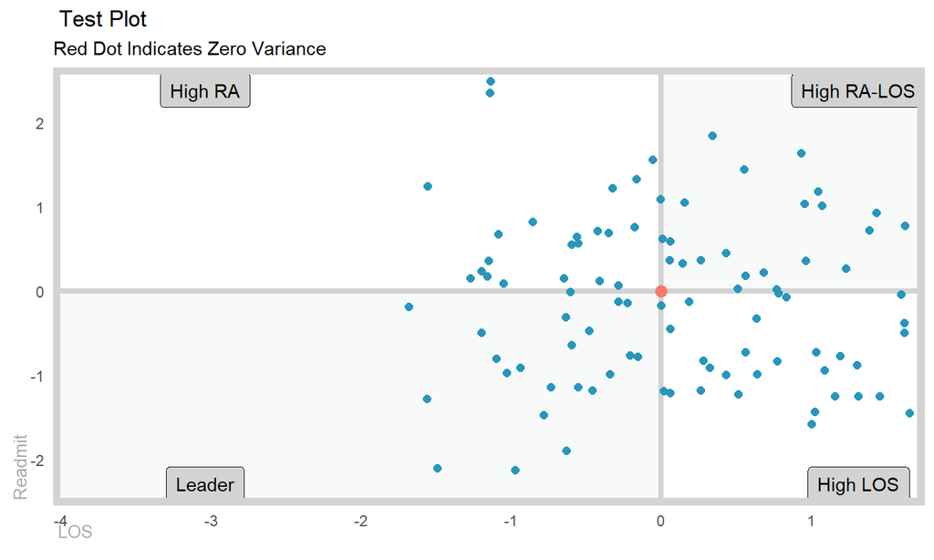

## `healthyR.ts`

What is `healthyR.ts`

Site: https://www.spsanderson.com/healthyR.ts/

The intent is that it be a easy to use verb framework for quick modeling of time-series data.

It is experimental.

In this section we are going to go over the processes of model tuning.

## Time Series Data

For this we use the internal `AirPassengers` data set.

```r
data_ts <- AirPassengers

head(data_ts)
```

```
## [1] 112 118 132 129 121 135
```

## Transform to `tibble`

Most of the work done inside of `healthyR.ts` requires the use of a `tibble`, and where a `ts` object can be used, it is typically converted to a `tibble` internally to the function. This is done on purpose so that it works well with the rest of the `tidyverse`

```r
data_tbl <- ts_to_tbl(data_ts) %>%
  select(-index)

head(data_tbl, 5)
```

```
## # A tibble: 5 x 2
##   date_col   value
##   <date>     <dbl>
## 1 1949-01-01   112
## 2 1949-02-01   118
## 3 1949-03-01   132
## 4 1949-04-01   129
## 5 1949-05-01   121
```

## `ts` to `tibble`

With the function `ts_to_tbl()` we can take a time-series object and make it into a `tibble` object.

## Splits Oject

Now that we have our data, we need to make our time series split object. We use `timetk::time_series_split()`

```r
splits <- time_series_split(
    data_tbl
    , date_col
    , assess = 12
    , skip = 3
    , cumulative = TRUE
)

head(training(splits), 1)
```

```
## # A tibble: 1 x 2
##   date_col   value
##   <date>     <dbl>
## 1 1949-01-01   112
```

## Recipe

Now that we have our splits object we can go ahead and make the recipe. For this we will use `ts_auto_recipe()` which creates four different recipes and outputs them into a list object.

```r
rec_objs <- ts_auto_recipe(
  .data       = data_tbl
  , .date_col = date_col
  , .pred_col = value
)
```

## Recipe (con’t)

Lets take a look at it

```r
rec_objs[[1]]
```

```
## Recipe
##
## Inputs:
##
##       role #variables
##    outcome          1
##  predictor          1
```

We are not going to look at all of them.

## Workflow Sets and `healthyR.ts`

We use `ts_wfs_mars()` in this example.

```r
ts_wfs_mars(
  .model_type = "earth",
  .recipe_list,
  .num_terms = 200,
  .prod_degree = 1,
  .prune_method = "backward"
)
```

## (con’t)

Lets make the workflowset objec.

```r
wfsets <- ts_wfs_mars(
  .model_type = "earth"
  , .recipe_list = rec_objs
)

wfsets
```

```
## # A workflow set/tibble: 4 x 4
##   wflow_id                  info             option    result
##   <chr>                     <list>           <list>    <list>
## 1 rec_base_mars             <tibble [1 x 4]> <opts[0]> <list [0]>
## 2 rec_date_mars             <tibble [1 x 4]> <opts[0]> <list [0]>
## 3 rec_date_fourier_mars     <tibble [1 x 4]> <opts[0]> <list [0]>
## 4 rec_date_fourier_nzv_mars <tibble [1 x 4]> <opts[0]> <list [0]>
```

## (con’t)

I tried to give reasonable defaults for all of the functions used in the `healthyverse` set of packages.

Many times hospitals, especially smaller non-academic or even small academic ones do not have a department of analysts. It could be that there are none or just one.

## Modeltime workflow

This workflow is outside of the scope of the `healthyverse` but necessary as it is an intermediate step before we get to the tuning process.

```r
wf_fits <- wfsets %>%
  modeltime_fit_workflowset(
    data = training(splits)
    , control = control_fit_workflowset(
     allow_par = FALSE
     , verbose = FALSE
    )
  )

models_tbl <- wf_fits %>%
  filter(.model != "NULL")
```

## (con’t)

You will see that we did `.model != "NULL"` this is because if a certain model tries to run, lets say an `ets` model where alpha < beta then it will fail and the `.model` output will be equal to `"NULL"`

Lets see the models_tbl

```r
models_tbl
```

```
## # Modeltime Table
## # A tibble: 4 x 3
##   .model_id .model     .model_desc
##       <int> <list>     <chr>
## 1         1 <workflow> REC_BASE_MARS
## 2         2 <workflow> REC_DATE_MARS
## 3         3 <workflow> REC_DATE_FOURIER_MARS
## 4         4 <workflow> REC_DATE_FOURIER_NZV_MARS
```

## Calibration

This is another part of the `modeltime` workflow that is used. We *calibrate* the data with the testing split using `testing(splits)`

```r
calibration_tbl <- models_tbl %>%
  modeltime_calibrate(new_data = testing(splits))

calibration_tbl
```

```
## # Modeltime Table
## # A tibble: 4 x 5
##   .model_id .model     .model_desc               .type .calibration_data
##       <int> <list>     <chr>                     <chr> <list>
## 1         1 <workflow> REC_BASE_MARS             Test  <tibble [12 x 4]>
## 2         2 <workflow> REC_DATE_MARS             Test  <tibble [12 x 4]>
## 3         3 <workflow> REC_DATE_FOURIER_MARS     Test  <tibble [12 x 4]>
## 4         4 <workflow> REC_DATE_FOURIER_NZV_MARS Test  <tibble [12 x 4]>
```

## Automatic Tuning

```r
output <- healthyR.ts::ts_model_auto_tune(
  .modeltime_model_id = 1,
  .calibration_tbl    = calibration_tbl,
  .splits_obj         = splits,
  .drop_training_na   = TRUE,
  .date_col           = date_col,
  .value_col          = value,
  .tscv_assess        = "12 months",
  .tscv_skip          = "3 months",
  .num_cores          = 1
)
```

## What happened?

We just automatically tuned the parameters of a model.

## Outputs

There are three sections of output from the function.

1. Data
2. Model Info
3. Plots

## Data

The function returns the following:

1. Calibration tibble from modeltime workflow
2. Calibration tuned tibble from tuned model
3. Time Series Cross Validation tibble
4. Tuned Model Results
5. Best tuned results
6. Time Series Cross Validation object (rsample object)

## Model Info

The following model information is available:

1. Model Specification
2. Parsnip Engine used
3. Plucked Model (The original model before tuning)
4. Tuned Workflow specification
5. Tuning Grid used
6. Tuned Time Series Cross Validation Workflow

## Plots

The following plots are returned;

1. Tuning Grid Plot
2. Cross Validation Plan

https://www.spsanderson.com/healthyR.ts/articles/auto-model-tune.html#data

## `healthyR.ai`

What is `healthyR.ai`?

It is experimental

Site: https://www.spsanderson.com/healthyR.ai/

## `healthyR.ai` Topics

We are going to talk about two functions and one workflow.

Functions:

1. `hai_histogram_facet_plot()`
2. `pca_your_recipe()`

Workflow:

1. Distribution Comparison of X

## Histogram Facet Plot

Function Call

```r
hai_histogram_facet_plot(
  .data,
  .bins = 10,
  .scale_data = FALSE,
  .ncol = 5,
  .fct_reorder = FALSE,
  .fct_rev = FALSE,
  .fill = "steelblue",
  .color = "white",
  .scale = "free",
  .interactive = FALSE
)
```

## Example Iris Data Not Scaled

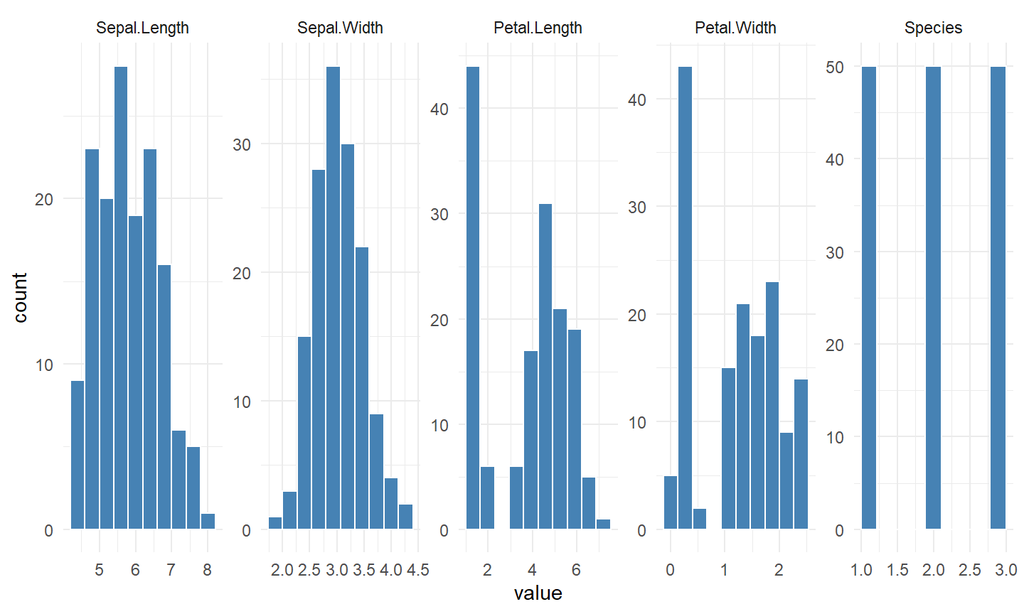

```r
hai_histogram_facet_plot(.data = iris)
```

## Example Iris Data Scaled

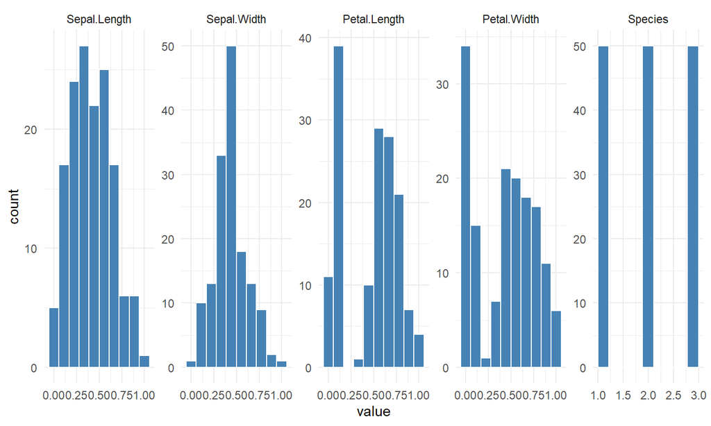

```r
hai_histogram_facet_plot(.data = iris, .scale_data = TRUE)
```

## Function Reference

[Histogram Facet Plot](https://www.spsanderson.com/healthyR.ai/reference/hai_histogram_facet_plot.html)

## PCA Your Recipe

What is PCA?

Principal component analysis (PCA) is a transformation of a group of variables that produces a new set of artificial features or components. These components are designed to capture the maximum amount of information (i.e. variance) in the original variables.

The function will automatically center and scale data along with dropping nzv columns before PCA is performed.

## The output

The function `pca_your_data()` returns invisibly a list object with a lot of information.

[Reference pca_your_data()](https://www.spsanderson.com/healthyR.ai/reference/pca_your_recipe.html)

## Lets test it out

```r
data_tbl <- healthyR_data %>%
    select(visit_end_date_time) %>%
    summarise_by_time(
        .date_var = visit_end_date_time,
        .by       = "month",
        value     = n()
    ) %>%
    set_names("date_col","value") %>%
    filter_by_time(
        .date_var = date_col,
        .start_date = "2013",
        .end_date = "2020"
    )

splits <- initial_split(data = data_tbl, prop = 0.8)

rec_obj <- recipe(value ~ ., training(splits)) %>%
    step_timeseries_signature(date_col) %>%
    step_rm(matches("(iso$)|(xts$)|(hour)|(min)|(sec)|(am.pm)"))
```

## Now lets PCA the Recipe

```r
output_list <- pca_your_recipe(rec_obj, .data = data_tbl)

names(output_list)
```

```
##  [1] "pca_transform"          "variable_loadings"      "variable_variance"
##  [4] "pca_estimates"          "pca_juiced_estimates"   "pca_baked_data"
##  [7] "pca_variance_df"        "pca_rotation_df"        "pca_variance_scree_plt"
## [10] "pca_loadings_plt"       "pca_loadings_plotly"    "pca_top_n_loadings_plt"
## [13] "pca_top_n_plotly"
```

## Lets Look at the Plots

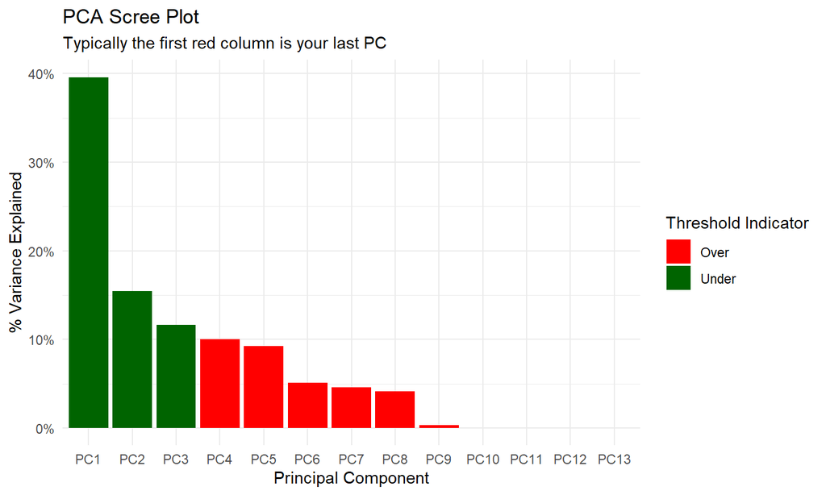

```r
output_list[["pca_variance_scree_plt"]]
```

## PCA Variance Scree Plot

This shows us how much variability is captured by each principal component

## PCA Loadings Plot

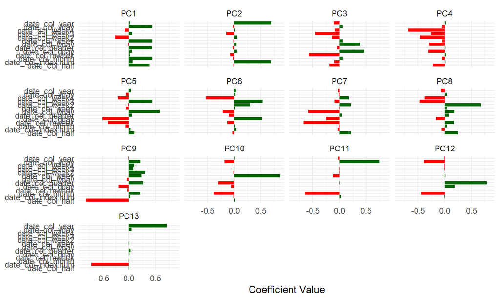

```r
output_list[["pca_loadings_plt"]]
```

## PCA Top N Loadings Plot

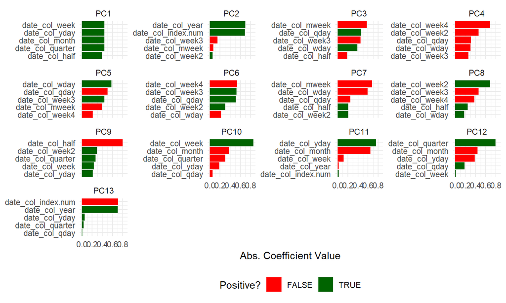

```r
output_list$pca_top_n_loadings_plt
```

## PC Loadings

Remember loadings are coefficients in linear combination predicting a varible by the standardized components, `pca_your_data()` will standardize your numberic components only for now.

[PCA On StatQuest](https://statquest.org/pca-clearly-explained/)

## Distribution Comparison

This is a workflow, meaning we pipe certain commands together to get the data. We will do this step by step. Here is an example of the full workflow:

```r
df <- hai_scale_zero_one_vec(.x = mtcars$mpg)

dist_comp_tbl <- hai_distribution_comparison_tbl(
    .x = df,
    .distributions = c("beta"),
    .normalize = FALSE
)

dist_tbl <- hai_get_density_data_tbl(.data = dist_comp_tbl)

dens_plt <- hai_density_plot(dist_tbl, distribution, x, y,
                             .interactive = FALSE)
```

## Scaling Data

So first we used `hai_scale_zero_one_vec()` which is a vectorized function that returns data on a vector from [0, 1] inclusive.

Did it here to showcase.

## Distribution Comparison Table

[Function Reference](https://www.spsanderson.com/healthyR.ai/reference/hai_distribution_comparison_tbl.html)

The end user can choose from several different distributions to make the comparison to the empirical data provided.

Might drop this in favor of moving the functionality to TidyDensity

## (con’t)

Lets see some output

```r
dist_comp_tbl
```

```
## # A tibble: 2 x 3
##   distribution dist_data  density_data
##   <chr>        <list>     <list>
## 1 beta         <dbl [32]> <density>
## 2 empirical    <dbl [32]> <density>
```

## (con’t)

This function as the library is experimental. There are some minor issues to flush out but the gist is that you can provide some vector x and choose from the list of supported distributions and get back certain information on them.

The vector x is passed through the resulting base `r_` distribution function and that creates the dist_data column.

The dist_data column is passed through to the `density()` function to get the density object. Right now the default n of 512 is used. May change this to the actual `n` or give user the option.

## Distribution Data

We used the function `hai_get_density_data_tbl()` which extracts the information we want from the dis_comp_tbl that was created.

```r
head(dist_tbl, 5)
```

```
## # A tibble: 5 x 3
## # Groups:   distribution [1]
##   distribution      x       y
##   <chr>         <dbl>   <dbl>
## 1 beta         -0.296 0.00915
## 2 beta         -0.293 0.0100
## 3 beta         -0.290 0.0109
## 4 beta         -0.287 0.0119
## 5 beta         -0.284 0.0130
```

## (con’t)

Simply what the function does is act as a sort of ‘getter’. It grabs the density data from the `dist_comp_tbl` and puts it into a `tibble`

[Function Reference](https://www.spsanderson.com/healthyR.ai/reference/hai_get_density_data_tbl.html)

## Density Comparison Plot

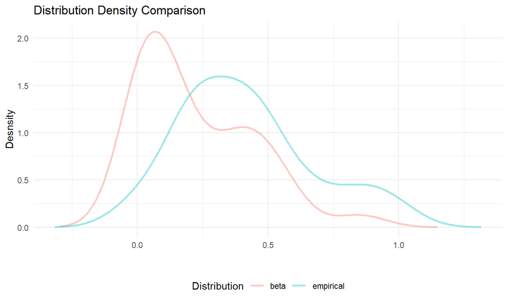

```r
dens_plt
```

## (con’t)

So what we see now is the densities plotted against each other. The work to get to this point was minimal, only three functions.

[Function Reference](https://www.spsanderson.com/healthyR.ai/reference/hai_density_plot.html)

## `healthyR.data`

It is stable

Site: https://www.spsanderson.com/healthyR.data/

## `TidyDensity`

It is stable

Site: https://www.spsanderson.com/TidyDensity/

## Underlying Packages

Heavy use of base R `actuar` for other distributions

Simple piped workflow, tries to be consistent with `tidyverse`

## Simple functions

`rnorm()` = `tidy_normal()`

Try to use sensible defaults.

Referred to as `tidy_` distribution functions.

Syntax that is in all `tidy_` distribution functions `.n` and `.num_sims` where `.n` is the number of randomly generated points and `.num_sims` is how many simulations should be run.

## Examples

## What to Generate

Generate five simulations of 100 points for normal and poisson distributions.

```r
n <- 100
ns <- 5
```

## Tidy Normal

```r
tn <- tidy_normal(.n = n, .num_sims = ns)
head(tn, 1)
```

```
## # A tibble: 1 x 7
##   sim_number     x     y    dx       dy     p     q
##   <fct>      <int> <dbl> <dbl>    <dbl> <dbl> <dbl>
## 1 1              1 -1.84 -3.55 0.000132   0.5  -Inf
```

```r
tn %>% group_by(sim_number) %>% summarise(mean_val = mean(y))
```

```
## # A tibble: 5 x 2
##   sim_number mean_val
##   <fct>         <dbl>
## 1 1            0.117
## 2 2            0.0242
## 3 3            0.0564
## 4 4           -0.0592
## 5 5           -0.0910
```

## Tidy Poisson

```r
tp <- tidy_poisson(.n = n, .num_sims = ns)
head(tp, 1)
```

```
## # A tibble: 1 x 7
##   sim_number     x     y    dx      dy     p     q
##   <fct>      <int> <int> <dbl>   <dbl> <dbl> <dbl>
## 1 1              1     1 -1.11 0.00423 0.368     0
```

```r
tp %>% group_by(sim_number) %>% summarise(mean_val = mean(y))
```

```
## # A tibble: 5 x 2
##   sim_number mean_val
##   <fct>         <dbl>
## 1 1              1.07
## 2 2              0.88
## 3 3              0.94
## 4 4              0.98
## 5 5              1.05
```

## What do we notice

We see that there is some random variation in the data…so what does it look like?

## Ploting

Hello `tidy_autoplot()`

Let’s take a look at both `tn` and `tp`

## Plot Tidy Normal

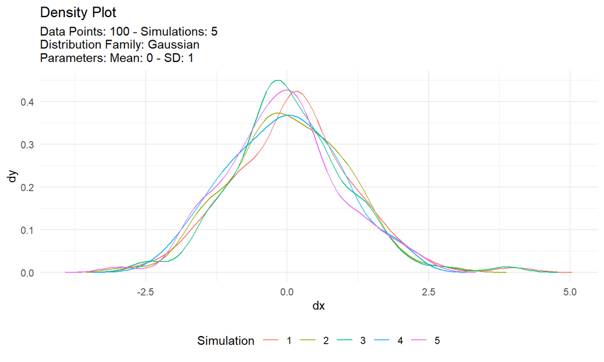

```r
tn %>% tidy_autoplot()
```

## Plot Tidy Poisson

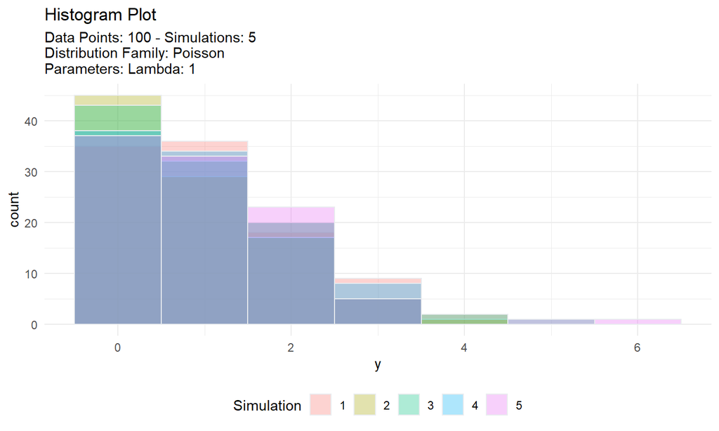

```r
tp %>% tidy_autoplot()
```

## What other plots are there?

[Function Reference](https://www.spsanderson.com/TidyDensity/reference/tidy_autoplot.html)

- “density”
- “probability”
- “quantile”
- “qq”

Plots can also be interactive. Tried to make them as automatic as possible.

## Combined Distributions

Can we combine distributions and visualize them? Yes!

We can do this with `tidy_combine_distributions()` and `tidy_combined_autoplot()`

How does it work?

## (con’t)

```r
combined_tbl <- tidy_combine_distributions(
    tidy_normal(),
    tidy_beta()
)
head(combined_tbl, 5)
```

```
## # A tibble: 5 x 8
##   sim_number     x      y    dx       dy     p       q dist_type
##   <fct>      <int>  <dbl> <dbl>    <dbl> <dbl>   <dbl> <fct>
## 1 1              1 -0.739 -2.65 0.000518 0.5   -Inf    Gaussian c(0, 1)
## 2 1              2  2.01  -2.52 0.00149  0.508   -2.05 Gaussian c(0, 1)
## 3 1              3  0.148 -2.39 0.00383  0.516   -1.74 Gaussian c(0, 1)
## 4 1              4  0.341 -2.26 0.00879  0.524   -1.54 Gaussian c(0, 1)
## 5 1              5 -0.152 -2.13 0.0180   0.533   -1.39 Gaussian c(0, 1)
```

## (con’t)

```r
combined_tbl %>%
    group_by(dist_type) %>%
    summarise(mean_val = mean(y)) %>%
    ungroup()
```

```
## # A tibble: 2 x 2
##   dist_type        mean_val
##   <fct>               <dbl>
## 1 Gaussian c(0, 1) -0.00243
## 2 Beta c(1, 1, 0)   0.538
```

## Visualize the Distributions Density

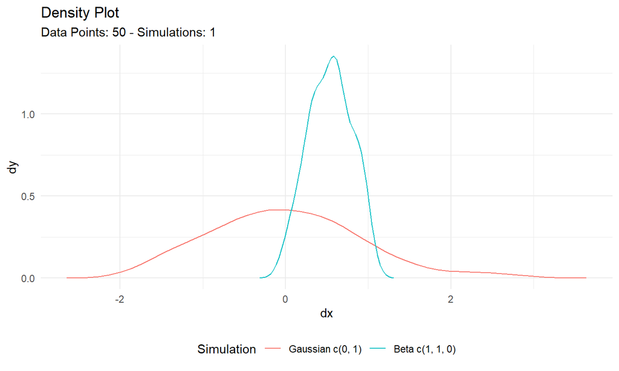

```r
combined_tbl %>% tidy_combined_autoplot()
```

## Visualize the Distributions QQ

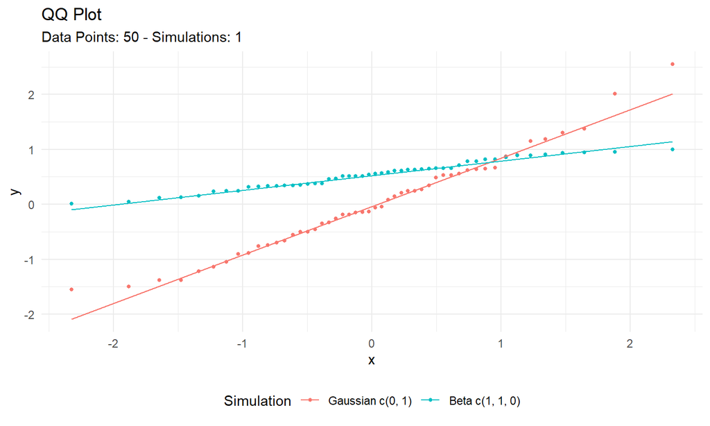

```r
combined_tbl %>% tidy_combined_autoplot(.plot_type = "qq")
```

## Multiple Versions of One distribution?

What if you want to see different parameters for a single distribution?

`tidy_multi_single_dist()` to the rescue!

## Function Call

```r
tidy_multi_single_dist(
  .tidy_dist = "tidy_normal",
  .param_list = list(
    .n = n,
    .mean = c(-1, 0, 1),
    .sd = 1,
    .num_sims = ns
  )
)
```

## Inspect

```r
tmn %>% with_groups(dist_name, summarise, mean(y))
```

```
## # A tibble: 3 x 2
##   dist_name         `mean(y)`
##   <fct>                 <dbl>
## 1 Gaussian c(-1, 1)   -0.976
## 2 Gaussian c(0, 1)    -0.0289
## 3 Gaussian c(1, 1)     0.934
```

## Visualize

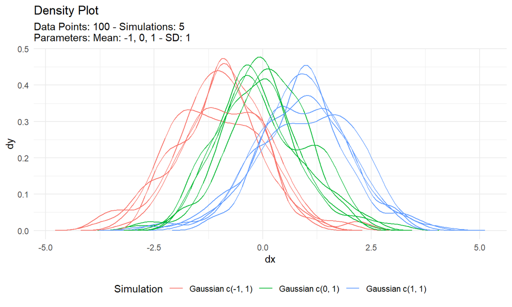

```r
tmn %>% tidy_multi_dist_autoplot()
```

## Parameter Estimation

Lets pick on the `beta` distribution.

Lets define a vector x

```r
x <- tidy_beta(.n = n, .shape1 = 0.1, .shape2 = 0.4)$y
```

## Beta Estimates

Outputs a list object, here we want to see the estimates tibble.

```r
util_beta_param_estimate(x)$parameter_tbl %>%
    select(dist_type, shape1, shape2, method)
```

```
## There was no need to scale the data.
```

```
## # A tibble: 3 x 4
##   dist_type  shape1 shape2 method
##   <chr>       <dbl>  <dbl> <chr>
## 1 Beta      16.2    83.8   Bayes
## 2 Beta       0.0967  0.500 NIST_MME
## 3 Beta       0.0993  0.513 EnvStats_MME
```

## Visualize the Empirical vs Estimated

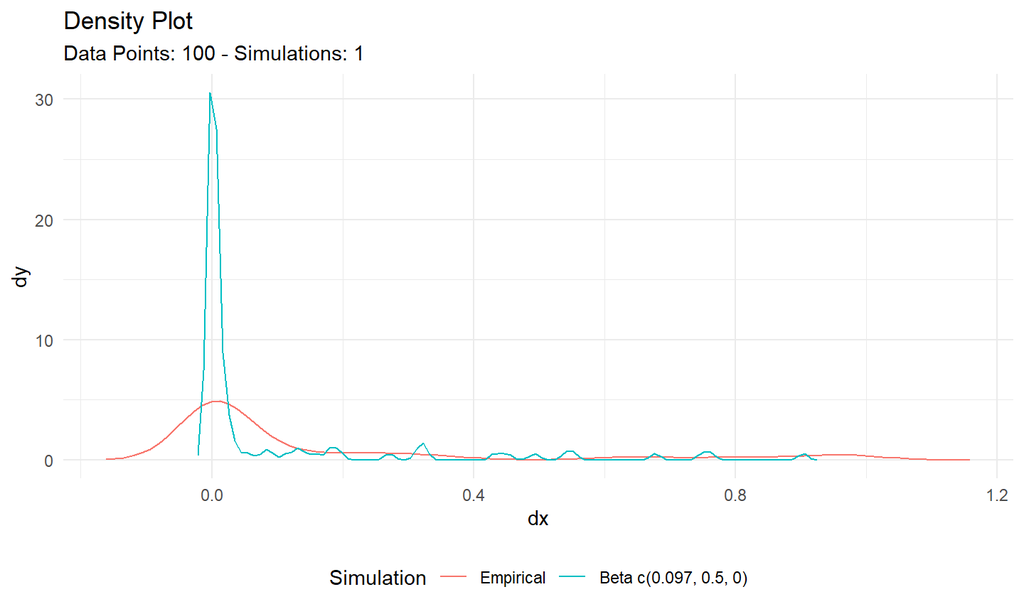

```r
util_beta_param_estimate(x)$combined_data_tbl %>%
  tidy_combined_autoplot()
```